# Pseudocode

## Warum Pseudocode?

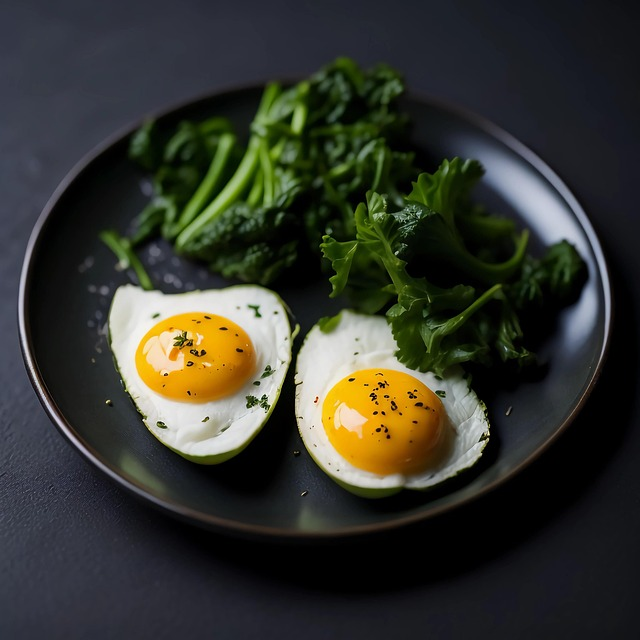

Quelle: susan-lu4esm auf pixabay

In Kochrezepten steht nie:

```
for(i=0; i<2; i++) {
   add(egg);
}
```

Sondern: `Zwei Eier hinzufügen`

Pseudocode ist genau das:  
*Kochen ohne Grammatikprüfung.*

Aufschreiben, was passieren soll -  
egal, *wie* die Programmiersprache es genau formuliert.

## WENN-Struktur

#### Minimal

```
WENN bedingung DANN
    anweisungen
ENDE WENN
```

#### Beispiel

```
WENN Benutzername ist leer DANN
    AUSGABE "Bitte Namen eingeben."
ENDE WENN
```

#### Alternativ-Bedingung

```
WENN bedingung DANN
    anweisungen
SONST WENN andere_bedingung DANN
    anweisungen
ENDE WENN
```

#### Beispiel

```
WENN Punktzahl ≥ 92 DANN
    AUSGABE "Hervorragend"
SONST WENN Punktzahl ≥ 81
    AUSGABE "Gut!"
ENDE WENN
```

## WENN: Alternativ-Bedingungen

#### Alternativ-Bedingungen

```
WENN bedingung DANN
    anweisungen
SONST WENN andere_bedingung DANN
    anweisungen
SONST
    anweisungen
ENDE WENN
```

#### Beispiel

```
WENN Punktzahl ≥ 81 DANN
    AUSGABE "Gut!"
SONST WENN Punktzahl ≥ 50 DANN
    AUSGABE "Geschafft!"
SONST
    AUSGABE "Dann eben Nachprüfung."
ENDE WENN
```

- DANN ist Pflicht.
- SONST WENN wird ausgeschrieben (nicht etwa ELSE IF).
- ENDE WENN ist Pflicht - auch bei kurzen Blöcken!

## FÜR-Schleifen (Zählschleife)

#### Standard-Variante

```
FUER i VON start BIS ende WIEDERHOLE
    anweisungen
ENDE FUER
```

#### Beispiel

```
FUER i VON 0 BIS 2 WIEDERHOLE
    hinzufügen(Ei)
ENDE FUER
```

## FÜR-Schleifen: Schrittweite

#### Schrittweite

```
FUER i VON 1 BIS 10 IN SCHRITTEN VON 2
    anweisungen
ENDE FUER
```

#### Beispiel

```
FUER i VON 1 BIS 10 IN SCHRITTEN VON 2
    AUSGABE i
ENDE FUER
```

## FÜR-Schleifen: Abwärts

#### Rückwärts-Zähler

```
FUER i VON 10 BIS 1
    anweisungen
ENDE FUER
```

#### Beispiel

```
// Countdown

FUER i VON 10 BIS 1
    AUSGABE i
ENDE FUER
```

## FUER JEDES (For-Each)

```
FUER JEDES element IN sammlung
    anweisungen
ENDE FUER
```

#### Beispiel

```
FUER JEDES element IN sammlung
    AUSGABE element
ENDE FUER
```

Achtung: `FUER JEDES element IN sammlung` liefert **das Element, nicht den Index**!  
Zugriff mit `element`, nicht mit `sammlung[element]`!

## FÜR-Schleifen kann man schachteln!

Punkte für Schachfiguren:  
Bauer: 1 Punkt; Springer und Läufer: je 3 Punkte; Turm: 5; Dame: 9  
König: unendlich, da er nicht eingetauscht werden kann (Verlust = Spielende)  
Der Einfachheit halber unterscheiden wir nicht zwischen schwarz und weiß.

```
FUNKTION BauernAufSchachbrettZählen
    zaehler = 0
    FÜR i VON 1 BIS 8
        FÜR j VON 1 BIS 8
            WENN Feld[i][j] == 1
                zaehler = zaehler + 1
            ENDE WENN
        ENDE FÜR
    ENDE FÜR

    RÜCKGABE zaehler
ENDE FUNKTION
```

## SOLANGE (While)

```
SOLANGE bedingung
    anweisungen
ENDE SOLANGE
```

#### Beispiel

```
SOLANGE KontoStand < 0
    AUSGABE "Bitte Konto ausgleichen"
ENDE SOLANGE
```

## WIEDERHOLE BIS (Do-Until)

```
WIEDERHOLE
    anweisungen
BIS bedingung
```

Bedingung steht unten!

#### Beispiel

```
WIEDERHOLE
    AUSGABE "Passwort falsch"
BIS Passwort = korrekt
```

**Wird mindestens 1x ausgeführt**

## Ein-/Ausgabe

#### Eingabe

```
LIES x
```

```
AUSGABE "Text"

ausgabe("Text")
```

## Variablen und Operationen

```
# Zuweisung

x = 5

# Arrayzugriff

liste[i]

# Länge

laenge(liste)

# Modulo

z MOD 2
```

## Methoden / Funktionen und Klassen

#### Methode / Funktion

```
METHODE name(parameter): Rueckgabetyp
    ...
    RUECKGABE wert
ENDE METHODE
```

#### Klasse

```
KLASSE Name
    attribute
    methoden
ENDE KLASSE
```

**Einrückungen beachten!**

## Methoden ohne Rückgabe

Es gibt auch Methoden **ohne Rückgabewerte**.

```
METHODE name(parameter)
    ...
ENDE METHODE
```

**Prüfungsrelevant (Lernkarte): Funktion vs. Prozedur**

Eine **Funktion** liefert einen **Rückgabewert.**  
Eine **Prozedur** liefert **keinen** Rückgabewert!

- Beide führen Anweisungen aus.
- Funktionen können in Ausdrücken verwendet werden, z. B. `x = f(a, b)`;  
  Prozeduren können nicht in Ausdrücken verwendet werden.

## Algorithmen: Akkumulator

```
summe = 0
FUER JEDES z IN zahlen
    summe = summe + z
ENDE FUER
RUECKGABE summe
```

## Algorithmen: Zähler

```
anzahl = 0
FUER JEDES z IN zahlen
    WENN z MOD 2 == 0 DANN
        anzahl = anzahl + 1
    ENDE WENN
ENDE FUER
RUECKGABE anzahl
```

Zählt?

… Anzahl der geraden Zahlen

## Algorithmen: Maximum, Minimum

```
max = liste[0]
FUER JEDES z IN liste
    WENN z > max DANN
        max = z
    ENDE WENN
ENDE FUER
```

```
min = liste[0]
FUER JEDES z IN liste
    WENN z < min DANN
        min = z
    ENDE WENN
ENDE FUER
```

## Algorithmen: Lineare Suche

```
gefunden = FALSCH
FUER JEDES z IN liste
    WENN z == gesucht DANN
        gefunden = WAHR
    ENDE WENN
ENDE FUER
```

## Algorithmen: Bubble Sort

```
FUER i VON 0 BIS laenge(liste)-1
    FUER j VON 0 BIS laenge(liste)-2
        WENN liste[j] > liste[j+1] DANN
            temp = liste[j]
            liste[j] = liste[j+1]
            liste[j+1] = temp
        ENDE WENN
    ENDE FUER
ENDE FUER
```

## Passwortprüfung

```
LIES passwort
WENN laenge(passwort) < 8 DANN
    AUSGABE "Passwort zu kurz"
SONST WENN NICHT enthaeltZiffer(passwort) DANN
    AUSGABE "Keine Ziffer enthalten"
SONST
    AUSGABE "Passwort akzeptiert"
ENDE WENN
```

## IHK-Prüfungsfallen

- Fehlende Blockenden  
  ENDE WENN, ENDE FUER, ENDE SOLANGE,  
  ENDE METHODE
- Falsche Operatoren  
  = Zuweisung  
  == Vergleich
- Keine Englischsprachigen Keywords  
  KEIN if, else, while, for, return
- Keine Klammern  
  { } nicht verwenden  
  Keine ( ) bei Kontrollstrukturen

## IHK Stilregeln

- Einrückung empfohlen
- Schlüsselwörter `GROß` schreiben
- Variablennamen `klein` schreiben
- keine unnötigen Leerzeilen
- Kommentare sparsam einsetzen
- keine Sprache nachahmen!  
  (kein Python-Stil, kein Java-Stil)

## Übersicht

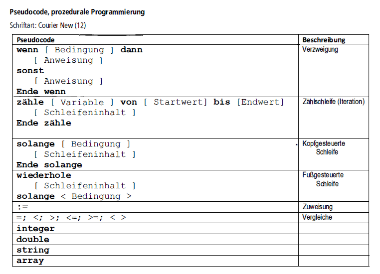

**Viel Erfolg mit Pseudocode!**

Zurück zur Übersicht LF10a